# Part II - Effect of Loan Characteristics on Borrowers APR

## by (SANGOTADE IDOWU)

## Investigation Overview

> The main purpose of this project is to summarise the characteristics of variables that can affect the borrowers APR and to get an idea about the relationship among multiple features using summary statistics aand data visualization.

## Dataset Overview

> The dataset consisted of borrower APRs and attributes of 113,937 loans. The attributes included original loan amount, borrower's Prosper rating, loan term, borrower's stated monthly income, as well as many other features such as borrower's employment status, debt to income ratio, current loan status etc

## Distribution of Borrower APR

> The data shows that most of the loans has APR of less than 0.42.the distribution also looks multimodal as the we have peaks values at 0.1, 0.2, 0.3 and between 0.3 and 0.4

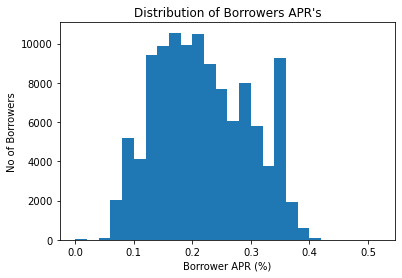

## Distribution of Loan Amount

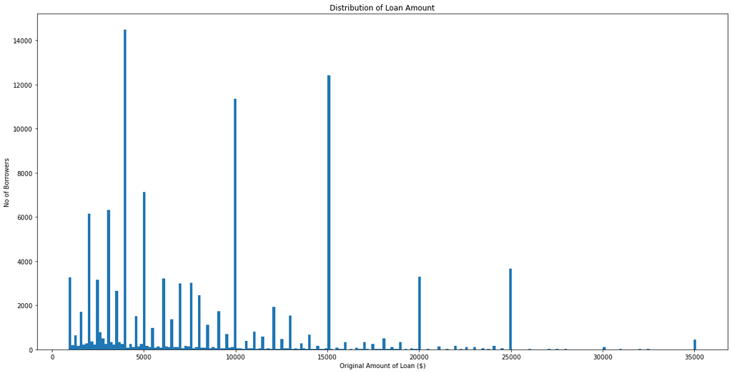

## Bivariate Exploration of Numerical Values

> The Pearson correlation coefficient of borrower APR and loan original amount is -0.3229 which agrees with my prediction earlier, that is the more the loan amount, the lower the APR. The loan original amount is positively correlated with the stated monthly income which makes sense since borrowers with more monthly income can request to loan more money.loan original amount is also positively correlated with employstatus duration which also make sense since i expect that has stayed on job longer will have the higher propensity to pay back there loans

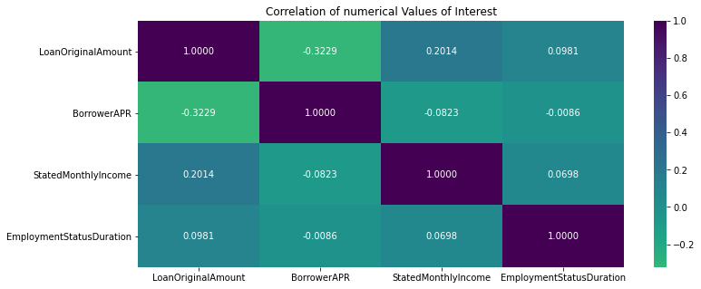

## Borrower APR against Prosper Rating

> The borrower APR decreases with the better rating. It means that the Prosper rating has a strong effect on borrower APR. Borrowers with better rating also have larger monthly income and loan amount

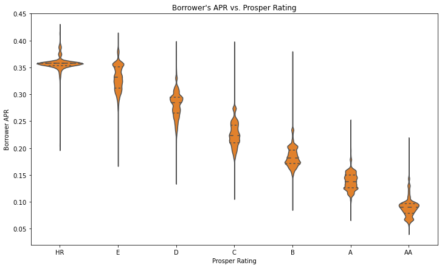

## Borrower APR against Rating and Term

> From the visualization, we can see that borrower APR decrease with the increase of borrow term for people with HR-C prosper ratings. For people with B-AA ratings, the APR increase with the increase of borrower's term

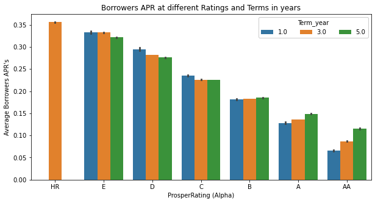